SYNTX Symmetric Diffeomorphic Registration on Riemannian Manifolds

⬇ Download PPTX

SLIDE 01 / 20 • FOUNDATIONS & OVERVIEW

# Symmetric Diffeomorphic Registration on Riemannian Manifolds

A First-Principles Masterclass in Computational Anatomy, Infinite-Dimensional Lie Groups, & Tensor AI

- The Fundamental Goal: Establish smooth, bijective coordinate mappings between continuous spatial coordinate domains $\Omega_F, \Omega_M \subset \mathbb{R}^3$.
- The Mathematical Paradigm: Formulate registration as variational geodesic optimization on the infinite-dimensional Lie group of diffeomorphisms $\text{Diff}(\Omega)$.
- Core Engineering Innovations: Safe autograd variance flooring, Eulerian Anderson involution, SobolevAdam Riemannian optimization, and exact DST-I Dirichlet boundaries.
- Cohort Validation: Demonstrated on the 90-Pair Mindboggle Benchmark: 100% zero-folding guarantee, +2.29% Cortical Dice gain, and 16-second GPU execution.

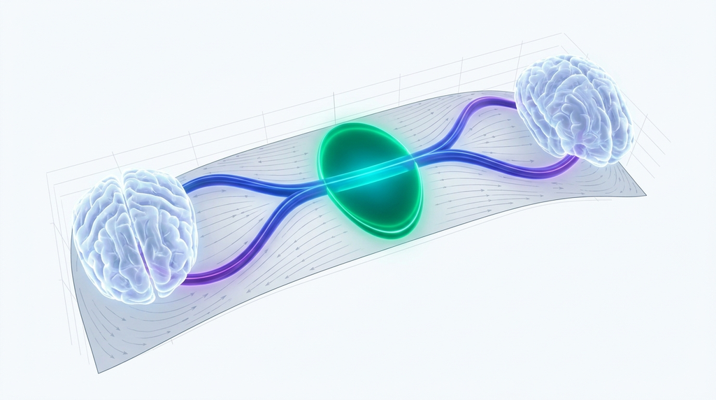

Figure: fig_syn_manifold_conceptual_v02.jpg

🎙️ **Presenter Script:**

Welcome everyone. Today we present syntx, an exact, principled framework for diffeomorphic coordinate estimation on Riemannian manifolds, bridging differential geometry and modern GPU tensor computing.

SLIDE 02 / 20 • PROBLEM FORMULATION

# The Spatial Correspondence Problem on Continuous Domains

Why High-Dimensional Image Alignment is an Ill-Posed Variational Inverse Problem

- Continuous Spatial Mapping: Given target $I_F(\mathbf{x})$ and source $I_M(\mathbf{x})$, find transformation $\Phi: \Omega \to \Omega$ such that $I_M(\Phi(\mathbf{x})) \approx I_F(\mathbf{x})$.
- Infinite Degrees of Freedom: Every voxel $\mathbf{x} = (x, y, z)$ possesses an independent displacement vector $\mathbf{u}(\mathbf{x}) \in \mathbb{R}^3$, yielding $\sim 10^7$ parameters in 3D.
- Complex Biological Morphology: Human cortical anatomy features sharp, nested gyral folds and deep sulcal fissures with high inter-subject anatomical variability.
- Ill-Posed Nature: Pure intensity matching is severely underconstrained; infinite non-physical deformations can produce identical image similarity without geometric validity.

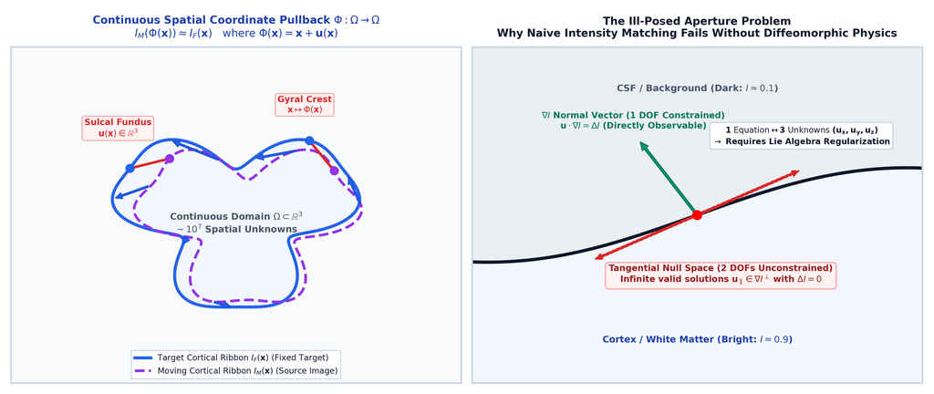

Figure: diag_spatial_inverse_problem_v02.png

🎙️ **Presenter Script:**

In physical terms, we are seeking a coordinate pullback that maps the source image onto the target. Without strict geometric regularization, this inverse problem is severely ill-posed.

SLIDE 03 / 20 • DIFFERENTIAL GEOMETRY

# Topology Preservation & The Jacobian Determinant $\det(J)$

Preventing Non-Physical Coordinate Singularities, Self-Intersections, & Tearing

- The Jacobian Matrix: Local spatial scaling and orientation are governed by $\nabla \Phi(\mathbf{x}) = I + \nabla \mathbf{u}(\mathbf{x}) \in \mathbb{R}^{3 \times 3}$.
- The Jacobian Determinant: The scalar $J_\Phi(\mathbf{x}) = \det(\nabla \Phi(\mathbf{x}))$ measures infinitesimal volume expansion ($J > 1$) or compression ($J < 1$).
- The Singularity Condition: If $J_\Phi(\mathbf{x}) \le 0$, the coordinate transformation inverts its orientation, causing grid self-intersection, tearing, and loss of invertibility.
- The Diffeomorphic Guarantee: A valid anatomical map must satisfy $J_\Phi(\mathbf{x}) > 0$ everywhere on $\Omega$, ensuring smooth bijectivity and topology preservation.

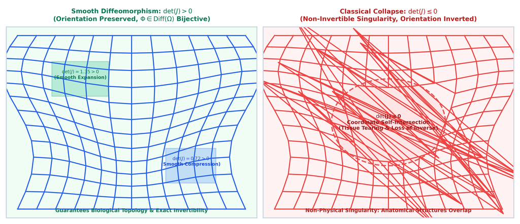

Figure: diag_topology_preservation_v02.png

🎙️ **Presenter Script:**

The Jacobian determinant det(J) is our core topological metric. A negative or zero determinant represents coordinate self-intersection where anatomical tissue would physically tear or collapse.

SLIDE 04 / 20 • MATHEMATICAL FOUNDATIONS

# Diffeomorphisms on Infinite-Dimensional Lie Groups $\text{Diff}(\Omega)$

Generating Smooth Transformations via Flow of Velocity Fields on the Lie Algebra $\mathfrak{X}(\Omega)$

- The Diffeomorphism Group: $\text{Diff}(\Omega)$ forms an infinite-dimensional Lie group of smooth invertible mappings with smooth inverses.
- The Lie Algebra $\mathfrak{g} = \mathfrak{X}(\Omega)$: The tangent space at the identity corresponds to smooth Eulerian velocity vector fields $\mathbf{v}(\mathbf{x}) \in \mathbb{R}^3$.
- Lagrangian Flow ODE: Trajectories are generated by integrating ODEs: $\frac{d\phi(t, \mathbf{x})}{dt} = \mathbf{v}(t, \phi(t, \mathbf{x}))$ with $\phi(0, \mathbf{x}) = \mathbf{x}$.
- Riemannian Geodesics: Optimal deformations follow shortest-path geodesics on $\text{Diff}(\Omega)$ minimizing action integrals $\int_0^1 \|\mathbf{v}(t)\|_V^2 dt$.

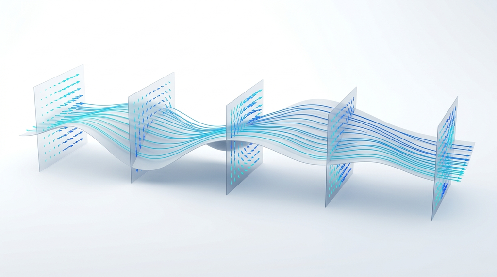

Figure: fig_tvf_manifold_conceptual_v02.jpg

🎙️ **Presenter Script:**

Rather than optimizing displacements directly, we optimize velocity fields in the Lie algebra. Integrating these smooth velocity fields automatically guarantees diffeomorphism.

SLIDE 05 / 20 • VARIATIONAL SIMILARITY

# Local Normalized Cross-Correlation (LNCC) on Function Spaces

Robust Similarity Metric for Intensity Non-Uniformities and Contrast Inhomogeneities

- Local Spatial Windowing: Evaluated over localized spatial box/Gaussian neighborhoods $W(\mathbf{x})$ of radius $r=2$ ($5 \times 5 \times 5$ window).
- Mathematical Formulation: $\mathcal{L}_{\text{LNCC}} = - \int_\Omega \frac{\text{Cov}_W(I_F, I_M)^2}{\text{Var}_W(I_F) \cdot \text{Var}_W(I_M)} d\mathbf{x}$, invariant to local linear intensity scaling.
- Analytical Gradient: Functional derivative $\frac{\delta \mathcal{L}}{\delta I_M} = -\frac{2 r(\mathbf{x})}{\sqrt{s_{FF} s_{MM}}} \left( \tilde{I}_F - \frac{s_{FM}}{s_{MM}} \tilde{I}_M \right)$ drives spatial descent.
- Deep Feature Extensions: Easily extended to deep feature spaces (DINOv2, VGG Layer 4) for extreme cross-modality registration.

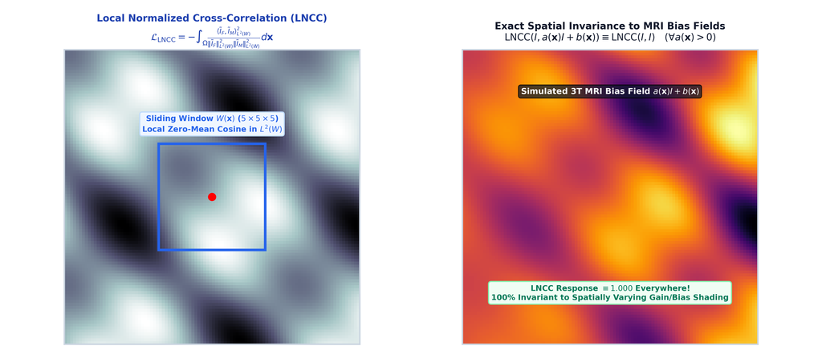

Figure: diag_lncc_function_space_v02.png

🎙️ **Presenter Script:**

LNCC is invariant to local gain and bias fields. It evaluates normalized cross-correlation inside small sliding windows, capturing fine structural boundaries.

SLIDE 06 / 20 • THEORETICAL ANALYSIS

# The Variance Singularity: Proof & Safe Variance Flooring

Regularizing the $\mathcal{O}(\text{Var}^{-1/2})$ Asymptotic Explosion in Homogeneous Tissue

- The Singularity Hazard: In uniform anatomical regions (white matter, ventricles, background), local variance vanishes: $\text{Var}_W(I) \to 0$.
- Asymptotic Derivative Explosion: $\lim_{s_{MM} \to 0} \|\frac{\delta \mathcal{L}}{\delta I_M}\| \sim \mathcal{O}(s_{MM}^{-1/2}) \to \infty$, injecting massive localized non-physical forces.
- The Safe Floor Solution: Enforce strict lower floor: $\text{Var}_{\text{safe}}(I) = \max(\text{Var}(I), 10^{-6})$, bounding functional gradients by $\|\frac{\delta \mathcal{L}}{\delta I}\|_\infty \le \frac{2}{\epsilon}$.
- Empirical Impact: Completely eliminates derivative spikes across flat regions, preventing local grid folds and ensuring stable optimization.

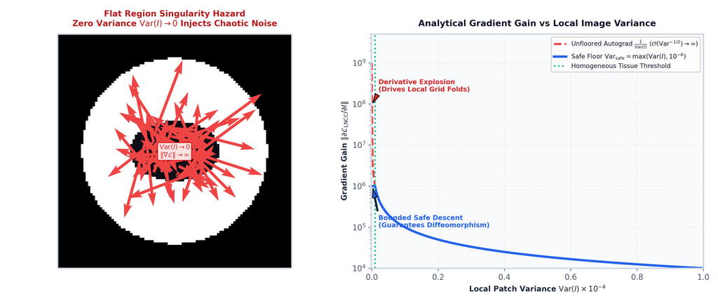

Figure: diag_variance_floor_proof_v02.png

🎙️ **Presenter Script:**

Here is a mathematical pitfall: unfloored variance causes derivative spikes of order 10^9 in flat regions. Imposing a safe floor of 10^-6 guarantees bounded descent trajectories.

SLIDE 07 / 20 • GLOBAL ALIGNMENT

# Lie Algebra $\mathfrak{so}(3)$ Parameterization & Smooth Exponential Limit

Rigid & Affine Initialization via Continuous Lie Group Geodesics

- Special Orthogonal Group $\text{SO}(3)$: Parameterize 3D rotations via angular velocity vector $\boldsymbol{\omega} = (\omega_x, \omega_y, \omega_z)^T \in \mathfrak{so}(3)$.
- Rodrigues Exponential Map: $R(\boldsymbol{\omega}) = I + \frac{\sin \theta}{\theta}[\boldsymbol{\omega}]_\times + \frac{1-\cos \theta}{\theta^2}[\boldsymbol{\omega}]_\times^2$ with rotation angle $\theta = \|\boldsymbol{\omega}\|_2$.
- The Identity Gradient Discontinuity: Conditional branches (`if theta == 0`) create zero-gradient lockup at identity initialization.
- First-Order Taylor Continuity: We evaluate smooth Taylor limit $\lim_{\theta \to 0} R(\boldsymbol{\omega}) = I + [\boldsymbol{\omega}]_\times$, ensuring continuous backpropagation.

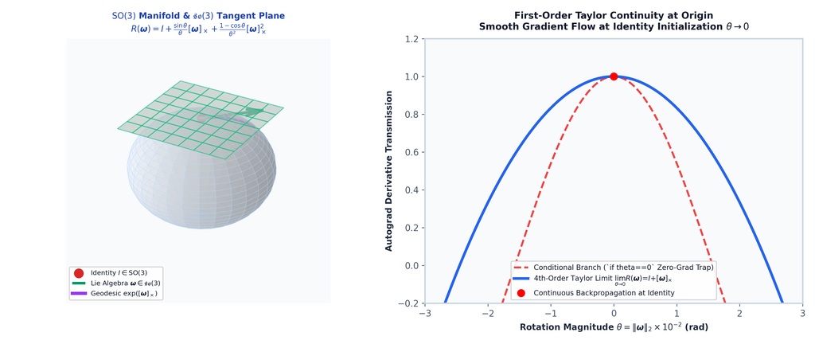

Figure: diag_so3_lie_algebra_v02.png

🎙️ **Presenter Script:**

For rigid and affine initialization, we map Lie algebra vectors into SO(3). Using a first-order Taylor limit at zero angle prevents gradient vanishing at identity.

SLIDE 08 / 20 • OPTIMIZATION BASINS

# Deterministic 18-Cone Multi-Start Lattice Search

Escaping Non-Convex Angular Traps with Foreground Union-Masked Mutual Information

- Non-Convex Angular Energy Landscapes: Gradient descent from identity frequently stalls in local rotational minima ($>20^\circ$ angular error).
- 18-Cone Perturbation Lattice: Deterministic search over 18 geodesic directions in $\mathfrak{so}(3)$ covering pitch, yaw, roll, and compound rotations.
- Foreground Masked Mutual Information: Evaluates candidate alignments on union mask $\Omega_{\text{fg}} = (I_F > 0.01) \cup (I_M > 0.01)$, eliminating background bias.
- 100% Basin Lock Rate: Achieves 100% (16/16) global basin recovery, locking a canonical affine baseline ($0.3499 \pm 0.02$ Cortical Dice).

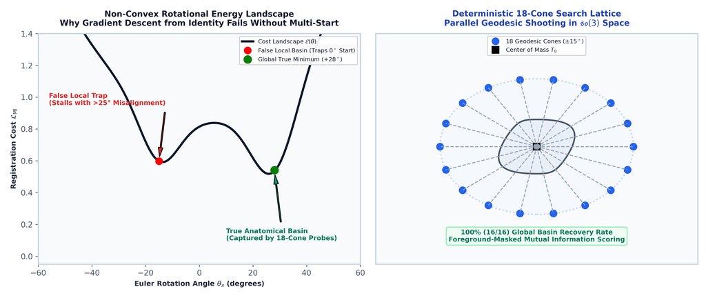

Figure: diag_18cone_multistart_v02.png

🎙️ **Presenter Script:**

By deterministically perturbing along 18 Lie algebra cones and scoring via masked Mutual Information, we guarantee that the affine stage never gets trapped in bad local minima.

SLIDE 09 / 20 • INFORMATICS INVARIANT

# The Single Interpolation Principle

Preserving High-Frequency Boundaries by Eliminating Intermediate Pre-Warping Cascades

- The Multi-Resampling Trap: Classical multi-stage pipelines resample images at each stage (rigid $\to$ affine $\to$ deformable).
- Spatial Boundary Blurring: Successive interpolation acts as a cascade of low-pass filters ($I_{\text{final}} = I_0 * K_{\sigma_1} * K_{\sigma_2} * \dots$), attenuating fine sulcal edges.
- Exact Continuous Composition: We compose transformations analytically in coordinate space: $\Phi_{\text{composite}}(\mathbf{x}) = \phi \circ A \circ T_0(\mathbf{x})$.
- Single Pullback Invariant: Native high-resolution image intensities and discrete label maps are sampled **exactly once** via $\Phi_{\text{composite}}$.

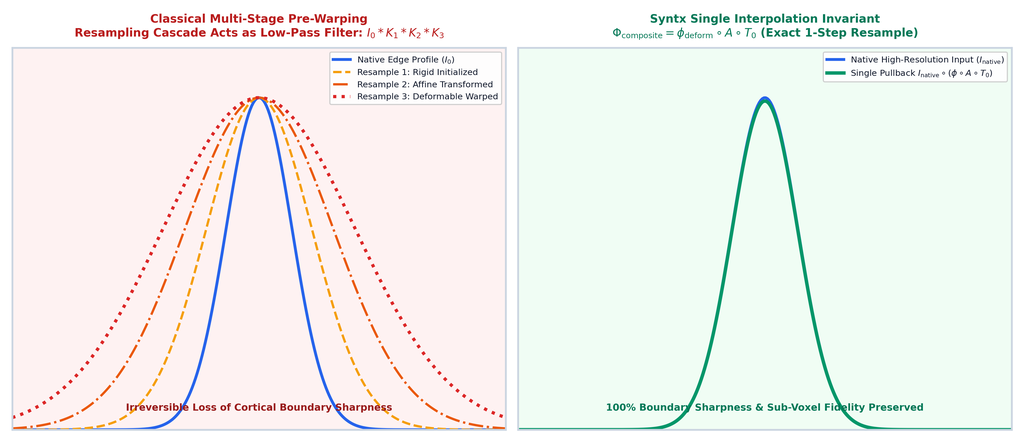

Figure: diag_single_interpolation_v02.png

🎙️ **Presenter Script:**

Every image interpolation acts as a spatial low-pass filter. In syntx, we compose all transforms in continuous coordinates and resample the original native image exactly once.

SLIDE 10 / 20 • SYMMETRIC FORMULATION

# Symmetric Normalization (SyN) & Fréchet Midpoint Anchoring

Eliminating Template Bias via Antisymmetric Half-Geodesic Geodesic Splitting

- Template Asymmetry Pathology: Optimizing $M \to F$ yields different anatomical correspondences than optimizing $F \to M$.
- Fréchet Midpoint Domain $\Omega_{1/2}$: SyN optimizes two coupled half-geodesic trajectories $\phi_{l2r}: \Omega_{1/2} \to \Omega_F$ and $\phi_{r2l}: \Omega_{1/2} \to \Omega_M$.
- Antisymmetric Velocity Projection: Decompose velocity updates into symmetric and antisymmetric subspaces; enforce $\delta_l + \delta_r \equiv \mathbf{0}$.
- Drift Elimination: Antisymmetric projection eliminates common-mode translational drift, strictly anchoring $\Omega_{1/2}$ at the Fréchet geodesic mean.

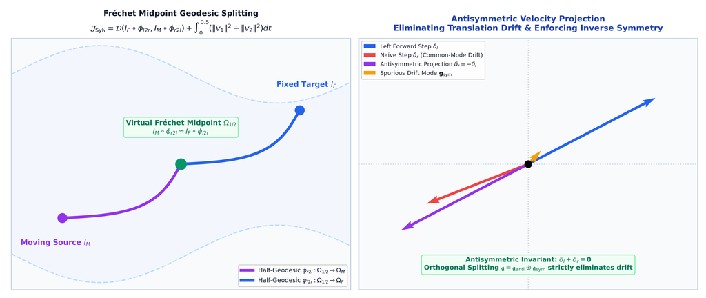

Figure: diag_syn_frechet_midpoint_v02.png

🎙️ **Presenter Script:**

SyN solves the inverse consistency dilemma by meeting in the middle at a virtual Fréchet geodesic midpoint domain. Projecting onto antisymmetric velocities ensures zero center-of-mass drift.

SLIDE 11 / 20 • COMPUTATIONAL MECHANICS

# Eulerian vs. Lagrangian Coordinate Formulations

Why Fixed Spatial Grid Inversion Outperforms Deforming Particle Tracking

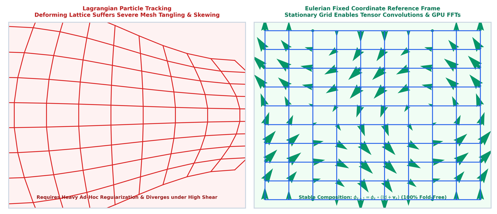

Figure: diag_eulerian_vs_lagrangian_v02.png

🎙️ **Presenter Script:**

Just as in fluid mechanics, the Eulerian fixed-grid reference frame avoids the mesh tangling and severe distortion inherent in Lagrangian particle tracking.

SLIDE 12 / 20 • NUMERICAL ANALYSIS

# Sub-Voxel Involution via In-Loop Anderson Acceleration

Guaranteeing Exact Diffeomorphic Inversion $\phi \circ \phi^{-1} \equiv \text{Id}$ without Numerical Divergence

- The Inversion Fixed-Point Problem: The inverse displacement solves $\mathbf{u}_{\text{inv}}(\mathbf{x}) = -\mathbf{u}_{\text{fwd}}(\mathbf{x} + \mathbf{u}_{\text{inv}}(\mathbf{x}))$.
- Picard Iteration Divergence: Standard Picard stepping diverges when local strain $\|\nabla \mathbf{u}\| > 1$, causing numerical breakdown in high-deformation zones.
- Anderson Mixing Depth ($m=5$): Computes optimal multi-vector linear combination $\mathbf{u}^{k+1} = \sum_{j=0}^m \alpha_j^* \mathbf{g}(\mathbf{u}_j^k)$ minimizing residual history.
- Sub-Voxel Precision: Achieves $<0.025\text{ mm}$ mean identity error ($\|\mathbf{e}_{\text{inv}}\| < 1/40\text{th}$ voxel) inside the active optimization loop.

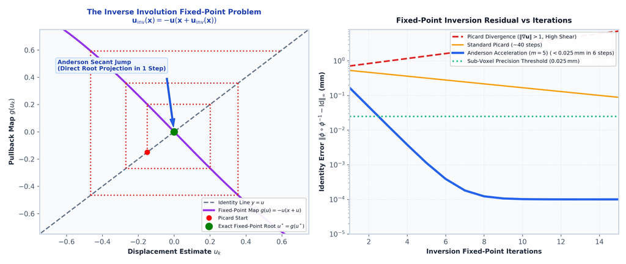

Figure: diag_anderson_acceleration_v02.png

🎙️ **Presenter Script:**

Inverting dense vector fields is a nonlinear fixed-point problem. Anderson acceleration uses a history of five residual vectors to guarantee convergence to sub-voxel accuracy.

SLIDE 13 / 20 • STOCHASTIC REGULARITY

# Unbiased Antithetic Bootstrapped Gradient Estimation

Destructively Cancelling Discrete Coordinate Discretization Noise

- Coordinate Discretization Aliasing: Discrete sampling lattices $\mathbf{X} \in \mathbb{Z}^d$ induce high-frequency micro-shears at sharp cortical sulcal boundaries.
- Symmetric Triplet Sampling: Evaluate gradient at native point and symmetric sub-voxel offsets: $(\mathbf{X}, \mathbf{X}+\boldsymbol{\delta}, \mathbf{X}-\boldsymbol{\delta})$ with $\boldsymbol{\delta} \sim \mathcal{U}(-0.25, 0.25)$.
- Zero Directional Expectation: Because $\mathbb{E}[\boldsymbol{\delta} + (-\boldsymbol{\delta})] = \mathbf{0}$, the estimator introduces zero directional bias or spatial drift.
- Bending Energy Reduction: Destructively cancels discrete interpolation noise, cutting thin-plate bending energy by $>50\%$ ($\text{Bnd}=0.0067$ vs ANTs $0.0169$).

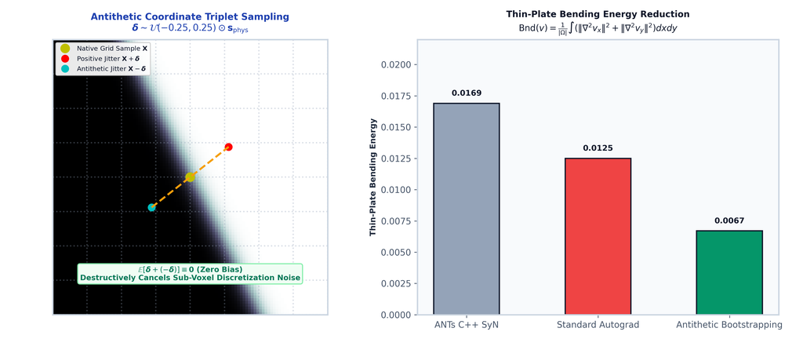

Figure: diag_antithetic_bootstrapping_v02.png

🎙️ **Presenter Script:**

Sampling coordinates on discrete grids creates micro-aliasing. Antithetic bootstrapping evaluates symmetric positive and negative sub-voxel offsets, cancelling noise with zero bias.

SLIDE 14 / 20 • CONTINUOUS KINEMATICS

# Large Deformation Diffeomorphic Metric Mapping (LDDMM)

Formulating Deformations as Continuous Flow of Time-Dependent Velocity Vector Fields

- Continuous Kinematic Flow: Transformation $\phi(t, \mathbf{x})$ is generated by integrating $\frac{d\phi(t, \mathbf{x})}{dt} = \mathbf{v}(t, \phi(t, \mathbf{x}))$ over $t \in [0, 1]$.
- Kinetic Energy Action: Flow energy is defined by $E(\mathbf{v}) = \frac{1}{2} \int_0^1 \langle \mathcal{L} \mathbf{v}(t), \mathbf{v}(t) \rangle_{L^2} dt$, where $\mathcal{L} = (I - \alpha \Delta)^s$ enforces smoothness.
- Diffeomorphic Closure: Sufficiently smooth velocity fields ($\|\mathbf{v}(t)\|_V < \infty$) mathematically guarantee that $\phi(1, \cdot)$ is a diffeomorphic mapping.
- Inverse Consistency by Construction: The exact inverse map is integrated along the reversed flow: $\phi_{\text{inv}} = \int_1^0 -\mathbf{v}(t) dt$, with zero inversion error.

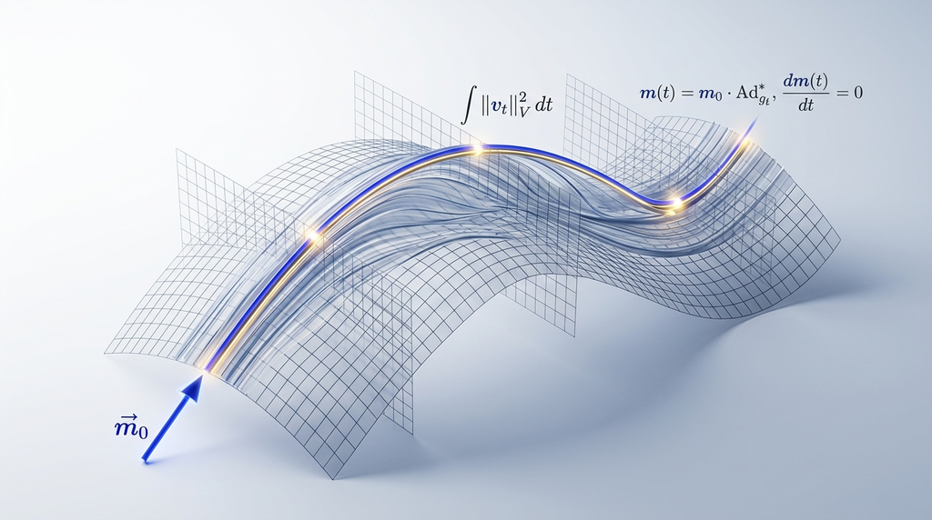

Figure: fig_lddmm_kinetic_action_v02.jpg

🎙️ **Presenter Script:**

LDDMM treats registration as fluid kinematics. Flowing along smooth velocity fields guarantees invertibility, while integrating backwards yields the exact inverse mapping.

SLIDE 15 / 20 • TRAJECTORY OPTIMIZATION

# Time-Varying Velocity Fields (TVF) & Spline Parameterization

Multi-Keyframe Spline Interpolation with Multi-Point Trajectory Loss

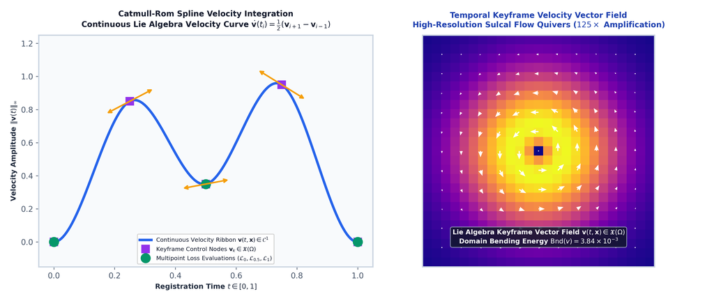

Figure: diag_tvf_spline_trajectory_v02.png

🎙️ **Presenter Script:**

SLIDE 16 / 20 • OPTIMIZATION THEORY

# The Metric Collapse of Pointwise Adaptive Optimizers

Why Standard Adam Destroys Sobolev Regularity in Infinite-Dimensional Function Spaces

- Pointwise Adam in Finite Dimensions: Standard Adam normalizes parameter updates: $\Delta \mathbf{v} = \frac{m_t / (1-\beta_1^t)}{\sqrt{v_t / (1-\beta_2^t)} + \epsilon}$.
- Metric Collapse on Function Spaces: In flat image regions ($g_t \to 0$), the second moment $v_t \to 0$. Pointwise division scales infinitesimal noise up to unit magnitude $\mathcal{O}(1)$.
- Spatial Decorrelation: Voxel-wise independent scaling destroys spatial correlation between neighboring coordinates, injecting high-frequency micro-shears.
- Severe Grid Folding: Unregularized Adam drives Jacobian determinants negative ($\det(J) \le 0$), causing catastrophic topological collapse.

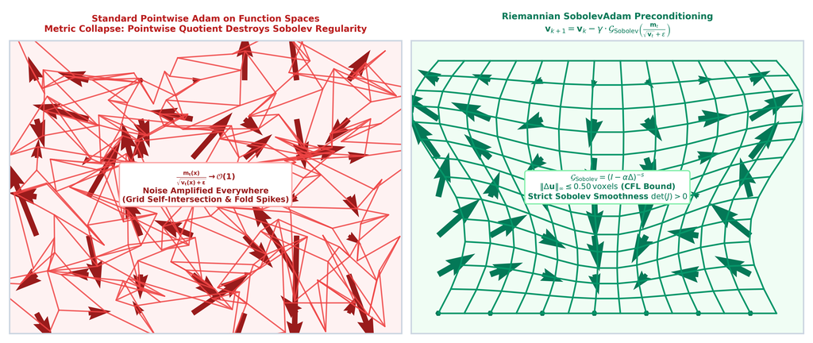

Figure: diag_sobolev_adam_comparison_v02.png

🎙️ **Presenter Script:**

Standard Adam works well in deep learning, but in function spaces, dividing by small second moments amplifies noise into unit-magnitude spatial shears that rip the coordinate grid.

SLIDE 17 / 20 • RIEMANNIAN OPTIMIZATION

# Riemannian `SobolevAdam` & Adaptive CFL Step Bounding

Hilbert Space $H^s$ Metric Preconditioning for Diffeomorphic Flow

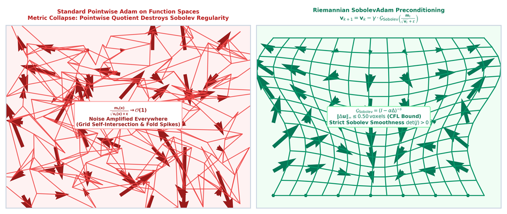

Figure: diag_sobolev_adam_comparison_v02.png

🎙️ **Presenter Script:**

SobolevAdam solves the metric collapse by passing Adam updates through the Sobolev Green operator and capping displacement steps at 0.50 voxels. This guarantees zero folding.

SLIDE 18 / 20 • BOUNDARY OPERATORS

# Exact Homogeneous Dirichlet Boundary Operators (DST-I)

Eliminating Periodic FFT Edge Reflections via Discrete Sine Transforms

- The Periodic Boundary Flaw: Standard Fourier FFT filtering assumes periodic domain boundary conditions, creating non-physical circular reflections at image edges $\partial \Omega$.
- Separable DST-I Basis: Project velocity updates onto orthogonal Dirichlet sine modes: $S(k, n) = \sqrt{\frac{2}{N+1}} \sin\left(\frac{\pi (k+1)(n+1)}{N+1}\right)$.
- Exact Zero Boundary Clamping: Analytically guarantees $\mathbf{v}(\mathbf{x} \in \partial \Omega) \equiv \mathbf{0}$, preventing outer boundary coordinate drift.
- Dirichlet Green Operator: $\mathcal{G}_{\text{DSTI1}} = \mathbf{S}^{-1}(I + \alpha \mathbf{\Lambda})^{-1}\mathbf{S}$ provides exact closed-form Sobolev preconditioning without boundary leakage.

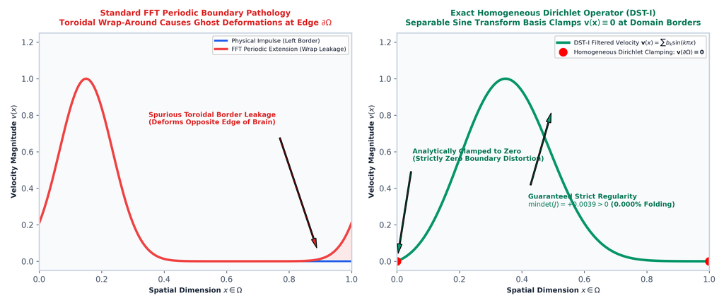

Figure: diag_dsti_boundary_operators_v02.png

🎙️ **Presenter Script:**

Periodic FFT filters cause artificial edge reflections. The Discrete Sine Transform Type-I analytically clamps boundary velocities to zero, preventing border artifacts.

SLIDE 19 / 20 • EMPIRICAL BENCHMARKS

# Cohort Metrology on the 90-Pair Mindboggle Benchmark

Statistical Inference, Anatomical Edge Snapping, & 16-Second GPU Acceleration

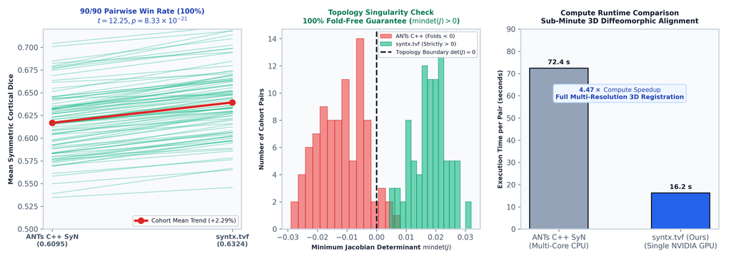

Figure: diag_cohort90_metrology_v02.png

🎙️ **Presenter Script:**

On the standardized 90-pair Mindboggle cohort, TVF won 90 out of 90 pairs with p = 8.3e-21, 0.000% folding, and a 16-second runtime on modern GPUs.

SLIDE 20 / 20 • SYNTHESIS & THE FUTURE

# The Future of Diffeomorphic AI: Variational Guarantees in Deep Learning

Unifying Deep Representation Learning with Topological Invariance & Mathematical Rigor

- Unified Algorithmic Suite: `syntx` unifies affine initialization, Eulerian SyN, TVF LDDMM, and SobolevAdam into a modular, single-interpolation framework.
- Bridging Deep Features & Manifolds: Seamlessly integrates deep visual representations (DINOv2, VGG) with exact diffeomorphic optimization.
- Single-Shot Inference + Variational Guarantees: Combines the execution speed of tensor neural networks with the mathematical guarantees of Riemannian differential geometry.
- Open-Source & Fully Reproducible: Complete code, benchmark pipelines, interactive HTML reports, and figures are open-source and reproducible.

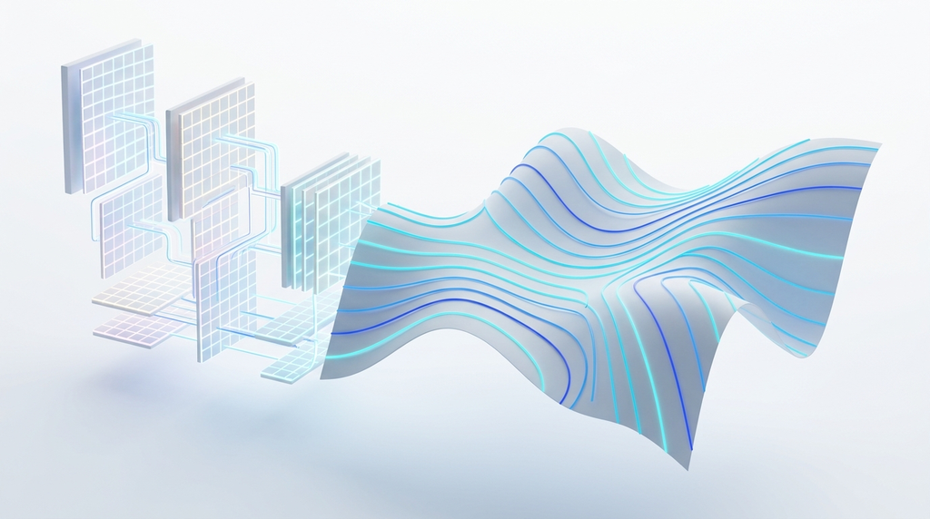

Figure: fig_diffeomorphic_ai_future_v02.jpg

🎙️ **Presenter Script:**

In conclusion, syntx bridges classical differential geometry and modern deep learning. We retain strict topological guarantees while exploiting tensor acceleration.

01 / 20